# STAT1005 Project 4.7

```python
import pandas as pd
import numpy as np
import seaborn as sns
import matplotlib.pyplot as plt
from matplotlib.pyplot import figure
import statsmodels.formula.api as sm
```

# Data Processing

## EU Data

```python
# import csv
eu_data = pd.read_csv('./data/eu_data.csv')

# drop unuse data
eu_data.drop(columns=['country_code', 'source', 'new_cases', 'number_sequenced', 'percent_cases_sequenced', 'valid_denominator', 'number_sequenced_known_variant', 'percent_variant'], inplace=True)

#variant of interest
voi = ["B.1.1.7", "B.1.351", "P.1", "B.1.617.2"]
# voi = [alpha, beta, gamma, delta]

eu_data = eu_data[eu_data.variant.isin(voi) == True]
eu_data.dropna(subset = ['number_detections_variant'], inplace=True)
eu_data.reset_index(drop=True, inplace=True)
eu_data
```

|  | country | year_week | variant | number_detections_variant |
| --- | --- | --- | --- | --- |
| 0 | Austria | 2020-40 | B.1.1.7 | 0.0 |
| 1 | Belgium | 2020-40 | B.1.1.7 | 0.0 |
| 2 | Bulgaria | 2020-40 | B.1.1.7 | 0.0 |
| 3 | Croatia | 2020-40 | B.1.1.7 | 0.0 |
| 4 | Cyprus | 2020-40 | B.1.1.7 | 0.0 |
| ... | ... | ... | ... | ... |
| 9249 | Romania | 2021-40 | P.1 | 0.0 |
| 9250 | Slovakia | 2021-40 | P.1 | 0.0 |
| 9251 | Slovenia | 2021-40 | P.1 | 0.0 |
| 9252 | Spain | 2021-40 | P.1 | 0.0 |
| 9253 | Sweden | 2021-40 | P.1 | 0.0 |

9254 rows × 4 columns

```python
eu_data_alpha = eu_data[eu_data.variant == "B.1.1.7"]
eu_data_beta = eu_data[eu_data.variant == "B.1.351"]
eu_data_gamma = eu_data[eu_data.variant == "P.1"]
eu_data_delta = eu_data[eu_data.variant == "B.1.617.2"]
```

## World Data

```python
# Variant of interest
voi = ["Alpha", "Beta", "Gamma", "Delta"]

world_data = pd.read_csv('./data/world_data.csv')
world_data.drop(columns=['num_sequences_total', 'perc_sequences'], inplace=True)
world_data.dropna(subset=['num_sequences'], inplace=True)
world_data = world_data[world_data.variant.isin(voi) == True]
world_data.reset_index(drop=True, inplace=True)
world_data
```

|  | location | date | variant | num_sequences |
| --- | --- | --- | --- | --- |
| 0 | Argentina | 11/5/2020 | Beta | 0.0 |
| 1 | Argentina | 11/5/2020 | Alpha | 0.0 |
| 2 | Argentina | 11/5/2020 | Gamma | 0.0 |
| 3 | Argentina | 11/5/2020 | Delta | 0.0 |
| 4 | Australia | 11/5/2020 | Beta | 0.0 |
| ... | ... | ... | ... | ... |
| 7067 | United States | 4/10/2021 | Delta | 11534.0 |
| 7068 | Italy | 10/10/2021 | Beta | 0.0 |
| 7069 | Italy | 10/10/2021 | Alpha | 0.0 |
| 7070 | Italy | 10/10/2021 | Gamma | 0.0 |
| 7071 | Italy | 10/10/2021 | Delta | 38.0 |

7072 rows × 4 columns

```python
world_data_alpha = world_data[world_data.variant == "Alpha"]
world_data_beta = world_data[world_data.variant == "Beta"]
world_data_gamma = world_data[world_data.variant == "Gamma"]
world_data_delta = world_data[world_data.variant == "Delta"]
```

# Analysis

## EU Data

### Graph EU Cases

```python
# for EU data only
def data_clean(data, country):
    data_processed = data.copy()
    data_processed = data_processed[data_processed.country == country].sort_values(by = ['number_detections_variant'], ascending=False)
    data_processed = data_processed.drop_duplicates(subset = ["year_week"]).sort_index()
    data_processed = data_processed.set_index('year_week')
    return data_processed

def plot_graph(country, label):
    plt.plot(country.index, country.number_detections_variant, label=label)
```

```python
# obtain list of countries on EU data
country_eu = eu_data.copy()
country_eu = country_eu.drop(columns=['variant', 'number_detections_variant', 'year_week'])
country_eu = country_eu.drop_duplicates(subset = ['country'])
country_eu.reset_index(drop=True, inplace=True)
```

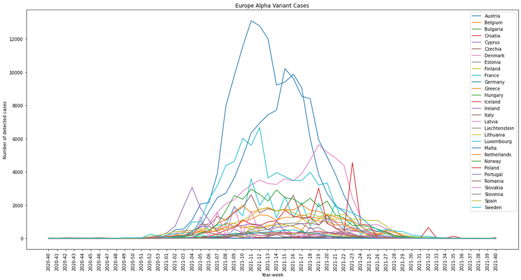

```python
# EU alpha variant cases
plt.figure(figsize=(20, 10))
plt.xticks(rotation=90)
plt.xlabel("Year-week")
plt.ylabel("Number of detected cases")
plt.title("Europe Alpha Variant Cases")
for i in country_eu['country']:
    plot_graph(data_clean(eu_data_alpha, i), i)
plt.legend()
```

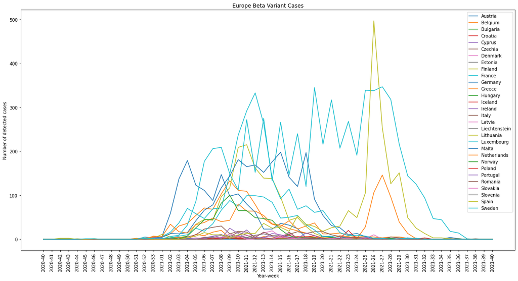

```python
# EU beta variant cases
plt.figure(figsize=(20, 10))
plt.xticks(rotation=90)
plt.xlabel("Year-week")
plt.ylabel("Number of detected cases")
plt.title("Europe Beta Variant Cases")
for i in country_eu['country']:
    plot_graph(data_clean(eu_data_beta, i), i)
plt.legend()
```

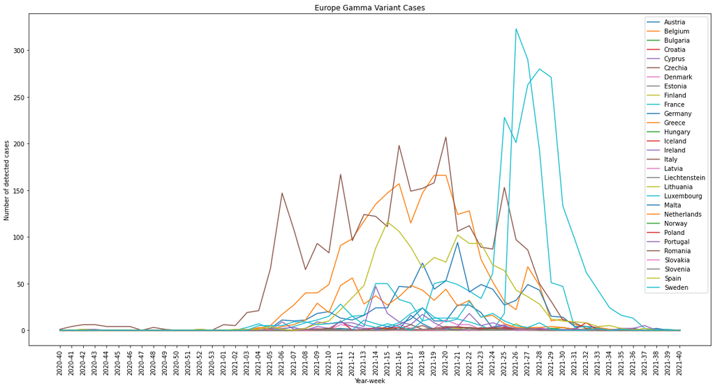

```python
# EU gamma variant cases
plt.figure(figsize=(20, 10))
plt.xticks(rotation=90)
plt.xlabel("Year-week")
plt.ylabel("Number of detected cases")
plt.title("Europe Gamma Variant Cases")
for i in country_eu['country']:
    plot_graph(data_clean(eu_data_gamma, i), i)
plt.legend()
```

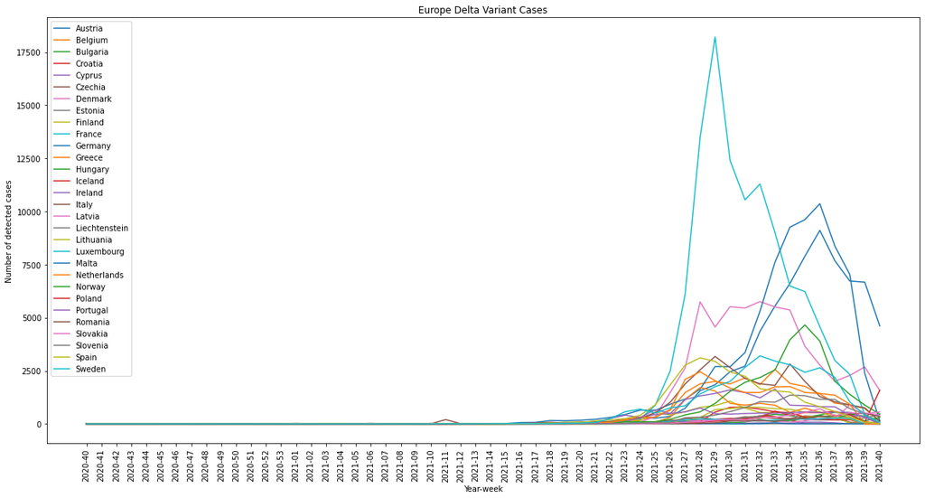

```python
# EU delta variant cases
plt.figure(figsize=(20, 10))
plt.xticks(rotation=90)
plt.xlabel("Year-week")
plt.ylabel("Number of detected cases")
plt.title("Europe Delta Variant Cases")
for i in country_eu['country']:
    plot_graph(data_clean(eu_data_delta, i), i)
plt.legend()
```

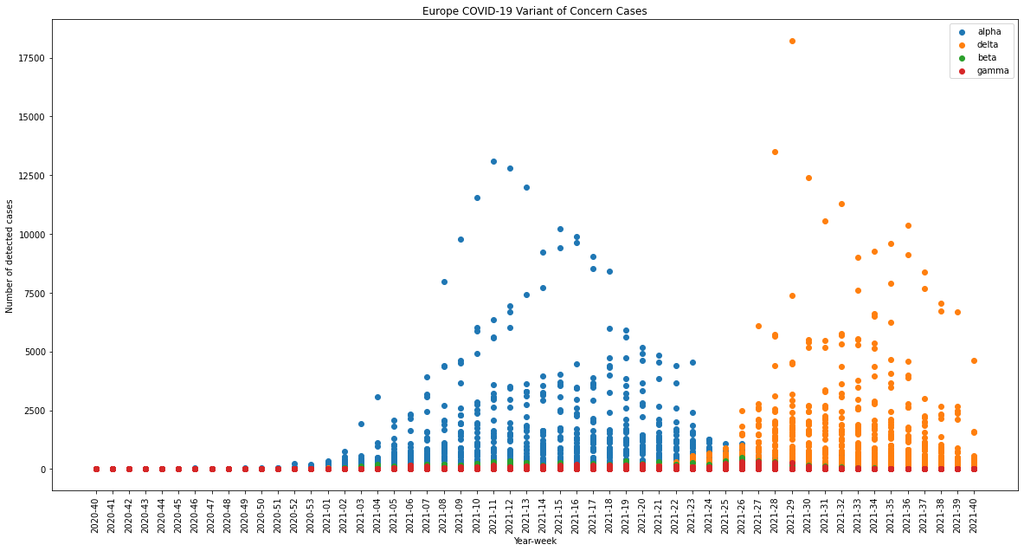

```python
# Overal graph for all EU variant of concern cases
plt.figure(figsize=(20, 10))
plt.xticks(rotation=90)
plt.xlabel("Year-week")
plt.ylabel("Number of detected cases")
plt.title("Europe COVID-19 Variant of Concern Cases")
plt.scatter(eu_data_alpha.year_week, eu_data_alpha.number_detections_variant, label="alpha")
plt.scatter(eu_data_delta.year_week, eu_data_delta.number_detections_variant, label="delta")
plt.scatter(eu_data_beta.year_week, eu_data_beta.number_detections_variant, label="beta")
plt.scatter(eu_data_gamma.year_week, eu_data_gamma.number_detections_variant, label="gamma")
plt.legend()
```

### Graph Observation Analysis

From the graph of each variant, it is possible to observe that the rise and drop in cases for a certain variant happens mostly at the same time frame throughout Europe. At the same time we can also observe that after the drop in cases, the variant is mostly no where to be found and replaced by another different variant.

While for the scattered graph, we can observe that the alpha COVID-19 mutation is the dominant strain in Europe before the number of cases drops and replaced by the delta variant.

*Thus, from all the graphs we can obtain that the pattern, location, and spreading of different variants is similar across Europe.*

### EU Regression and Correlation

```python
# Remove duplicate data
week = eu_data.copy()
week = week.drop(columns=['variant', 'number_detections_variant', 'country'])
week = week.drop_duplicates(subset = ['year_week'])
week.reset_index(drop=True, inplace=True)
```

```python
def ols_location_time(data):
    eu_data_var = data.copy()

    for i in range(len(week)):
        eu_data_var.replace(to_replace = week['year_week'][i], value = (i + 1), inplace= True)

    result = sm.ols(formula="number_detections_variant ~ country + year_week", data=eu_data_var).fit()
    print(result.summary())

    for i in range(len(country_eu['country'])):
        eu_data_var.replace(to_replace = str(country_eu['country'][i]), value = (i + 1), inplace= True)
    sns.heatmap(eu_data_var.corr(), vmin=-1, vmax=1, annot=True, cbar=False).set_title("Correlation Analysis", fontdict={'fontsize':12}, pad=12);
```

```
                                OLS Regression Results
=====================================================================================
Dep. Variable:     number_detections_variant   R-squared:                       0.094
Model:                                   OLS   Adj. R-squared:                  0.091
Method:                        Least Squares   F-statistic:                     31.79
Date:                       Sat, 04 Dec 2021   Prob (F-statistic):          8.33e-172
Time:                               10:01:38   Log-Likelihood:                -75057.
No. Observations:                       9254   AIC:                         1.502e+05
Df Residuals:                           9223   BIC:                         1.504e+05
Df Model:                                 30
Covariance Type:                   nonrobust
============================================================================================
                               coef    std err          t      P>|t|      [0.025      0.975]
--------------------------------------------------------------------------------------------
Intercept                  437.3247     47.675      9.173      0.000     343.871     530.779
country[T.Belgium]        -394.7733     65.757     -6.004      0.000    -523.672    -265.875
country[T.Bulgaria]       -598.7755     65.442     -9.150      0.000    -727.056    -470.495
country[T.Croatia]        -590.1133     66.353     -8.894      0.000    -720.180    -460.046
country[T.Cyprus]         -629.5348     66.699     -9.438      0.000    -760.280    -498.789
country[T.Czechia]        -584.3282     63.844     -9.152      0.000    -709.477    -459.180
country[T.Denmark]         119.0839     63.890      1.864      0.062      -6.154     244.322
country[T.Estonia]        -591.9029     64.053     -9.241      0.000    -717.460    -466.345
country[T.Finland]        -535.4441     63.284     -8.461      0.000    -659.495    -411.393
country[T.France]            7.7316     64.557      0.120      0.905    -118.814     134.277
country[T.Germany]         166.5457     62.697      2.656      0.008      43.646     289.445
country[T.Greece]         -530.8464     63.475     -8.363      0.000    -655.272    -406.420
country[T.Hungary]        -629.4493     68.194     -9.230      0.000    -763.124    -495.774
country[T.Iceland]        -604.0022     64.666     -9.340      0.000    -730.762    -477.243
country[T.Ireland]        -432.7893     63.686     -6.796      0.000    -557.627    -307.951
country[T.Italy]          -355.4486     60.369     -5.888      0.000    -473.784    -237.113
country[T.Latvia]         -605.5249     63.476     -9.539      0.000    -729.953    -481.097
country[T.Liechtenstein]  -628.0299     70.699     -8.883      0.000    -766.616    -489.444
country[T.Lithuania]      -530.1803     63.738     -8.318      0.000    -655.121    -405.239
country[T.Luxembourg]     -586.9260     63.375     -9.261      0.000    -711.154    -462.698
country[T.Malta]          -633.4869     65.632     -9.652      0.000    -762.139    -504.835
country[T.Netherlands]    -341.8292     62.745     -5.448      0.000    -464.824    -218.835
country[T.Norway]         -358.7774     63.375     -5.661      0.000    -483.006    -234.548
country[T.Poland]         -503.2981     63.784     -7.891      0.000    -628.329    -378.267
country[T.Portugal]       -527.0558     62.562     -8.425      0.000    -649.690    -404.421
country[T.Romania]        -615.0807     63.032     -9.758      0.000    -738.637    -491.525
country[T.Slovakia]       -559.7498     65.080     -8.601      0.000    -687.321    -432.179
country[T.Slovenia]       -519.5272     65.257     -7.961      0.000    -647.445    -391.609
country[T.Spain]          -359.9128     60.718     -5.928      0.000    -478.934    -240.892
country[T.Sweden]          -79.3440     61.900     -1.282      0.200    -200.683      41.995
year_week                    6.9418      0.572     12.140      0.000       5.821       8.063
==============================================================================
Omnibus:                    12512.837   Durbin-Watson:                   1.147
Prob(Omnibus):                  0.000   Jarque-Bera (JB):          3361378.043
Skew:                           7.736   Prob(JB):                         0.00
Kurtosis:                      95.077   Cond. No.                         961.
==============================================================================

Notes:
[1] Standard Errors assume that the covariance matrix of the errors is correctly specified.
```

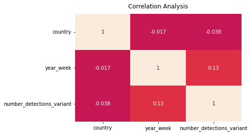

```python
# EU OLS Regression Result and correlation analysis
ols_location_time(eu_data)
```

```
                                OLS Regression Results
=====================================================================================
Dep. Variable:     number_detections_variant   R-squared:                       0.197
Model:                                   OLS   Adj. R-squared:                  0.188
Method:                        Least Squares   F-statistic:                     21.21
Date:                       Sat, 04 Dec 2021   Prob (F-statistic):          1.81e-101
Time:                               10:01:38   Log-Likelihood:                -21821.
No. Observations:                       2626   AIC:                         4.370e+04
Df Residuals:                           2595   BIC:                         4.389e+04
Df Model:                                 30
Covariance Type:                   nonrobust
============================================================================================
                               coef    std err          t      P>|t|      [0.025      0.975]
--------------------------------------------------------------------------------------------
Intercept                 1468.8940    109.734     13.386      0.000    1253.720    1684.068
country[T.Belgium]       -1084.0965    155.522     -6.971      0.000   -1389.057    -779.136
country[T.Bulgaria]      -1374.9226    152.029     -9.044      0.000   -1673.034   -1076.812
country[T.Croatia]       -1348.0140    148.984     -9.048      0.000   -1640.153   -1055.875
country[T.Cyprus]        -1447.5214    150.514     -9.617      0.000   -1742.662   -1152.381
country[T.Czechia]       -1358.8606    143.291     -9.483      0.000   -1639.837   -1077.884
country[T.Denmark]          36.2575    148.506      0.244      0.807    -254.945     327.460
country[T.Estonia]       -1357.6681    147.163     -9.226      0.000   -1646.237   -1069.099
country[T.Finland]       -1302.1092    144.714     -8.998      0.000   -1585.876   -1018.342
country[T.France]         -903.1980    153.155     -5.897      0.000   -1203.517    -602.879
country[T.Germany]         273.3422    145.868      1.874      0.061     -12.688     559.372
country[T.Greece]        -1225.8935    143.550     -8.540      0.000   -1507.379    -944.408
country[T.Hungary]       -1442.8941    158.839     -9.084      0.000   -1754.359   -1131.429
country[T.Iceland]       -1440.6054    150.977     -9.542      0.000   -1736.653   -1144.558
country[T.Ireland]       -1107.8564    144.700     -7.656      0.000   -1391.596    -824.117
country[T.Italy]          -941.5441    141.176     -6.669      0.000   -1218.373    -664.715
country[T.Latvia]        -1379.9716    145.456     -9.487      0.000   -1665.194   -1094.749
country[T.Liechtenstein] -1455.1469    168.924     -8.614      0.000   -1786.387   -1123.907
country[T.Lithuania]     -1239.6906    145.464     -8.522      0.000   -1524.928    -954.453
country[T.Luxembourg]    -1342.1591    147.169     -9.120      0.000   -1630.739   -1053.579
country[T.Malta]         -1449.5239    149.995     -9.664      0.000   -1743.647   -1155.401
country[T.Netherlands]    -848.2106    145.083     -5.846      0.000   -1132.701    -563.720
country[T.Norway]         -904.2405    143.527     -6.300      0.000   -1185.680    -622.801
country[T.Poland]        -1066.5250    145.456     -7.332      0.000   -1351.747    -781.303
country[T.Portugal]      -1264.1776    142.863     -8.849      0.000   -1544.314    -984.041
country[T.Romania]       -1425.5011    144.273     -9.881      0.000   -1708.402   -1142.600
country[T.Slovakia]      -1311.4237    143.225     -9.156      0.000   -1592.270   -1030.577
country[T.Slovenia]      -1255.2773    147.155     -8.530      0.000   -1543.830    -966.724
country[T.Spain]          -945.6530    140.189     -6.746      0.000   -1220.547    -670.759
country[T.Sweden]           13.0443    144.683      0.090      0.928    -270.661     296.750
year_week                   -0.4871      1.344     -0.362      0.717      -3.123       2.149
==============================================================================
Omnibus:                     2606.783   Durbin-Watson:                   1.378
Prob(Omnibus):                  0.000   Jarque-Bera (JB):           181756.686
Skew:                           4.700   Prob(JB):                         0.00
Kurtosis:                      42.658   Cond. No.                         941.
==============================================================================

Notes:
[1] Standard Errors assume that the covariance matrix of the errors is correctly specified.
```

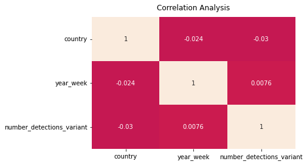

```python
# EU alpha variant OLS Regression Result and correlation analysis
ols_location_time(eu_data_alpha)
```

```
                                OLS Regression Results
=====================================================================================
Dep. Variable:     number_detections_variant   R-squared:                       0.244
Model:                                   OLS   Adj. R-squared:                  0.233
Method:                        Least Squares   F-statistic:                     23.09
Date:                       Sat, 04 Dec 2021   Prob (F-statistic):          4.05e-108
Time:                               10:01:38   Log-Likelihood:                -10951.
No. Observations:                       2181   AIC:                         2.196e+04
Df Residuals:                           2150   BIC:                         2.214e+04
Df Model:                                 30
Covariance Type:                   nonrobust
============================================================================================
                               coef    std err          t      P>|t|      [0.025      0.975]
--------------------------------------------------------------------------------------------
Intercept                   19.8216      4.457      4.447      0.000      11.081      28.562
country[T.Belgium]          -2.3313      6.205     -0.376      0.707     -14.500       9.837
country[T.Bulgaria]        -20.6542      6.082     -3.396      0.001     -32.582      -8.727
country[T.Croatia]         -20.0250      6.231     -3.214      0.001     -32.244      -7.806
country[T.Cyprus]          -20.7174      6.505     -3.185      0.001     -33.473      -7.961
country[T.Czechia]         -18.6613      6.016     -3.102      0.002     -30.460      -6.863
country[T.Denmark]         -17.5454      6.016     -2.916      0.004     -29.343      -5.747
country[T.Estonia]         -19.4909      6.038     -3.228      0.001     -31.331      -7.651
country[T.Finland]          11.5090      5.861      1.964      0.050       0.015      23.003
country[T.France]           69.7359      6.019     11.585      0.000      57.931      81.540
country[T.Germany]          18.4866      5.860      3.154      0.002       6.994      29.979
country[T.Greece]          -13.3981      5.843     -2.293      0.022     -24.857      -1.939
country[T.Hungary]         -20.7287      6.540     -3.170      0.002     -33.554      -7.904
country[T.Iceland]         -20.6467      6.037     -3.420      0.001     -32.487      -8.807
country[T.Ireland]         -18.5672      6.016     -3.086      0.002     -30.366      -6.769
country[T.Italy]           -16.1353      5.809     -2.777      0.006     -27.528      -4.743
country[T.Latvia]          -20.4043      5.935     -3.438      0.001     -32.043      -8.766
country[T.Liechtenstein]   -20.7287      6.540     -3.170      0.002     -33.554      -7.904
country[T.Lithuania]       -20.3736      6.038     -3.374      0.001     -32.215      -8.533
country[T.Luxembourg]        0.8210      5.897      0.139      0.889     -10.743      12.385
country[T.Malta]           -20.5365      6.314     -3.252      0.001     -32.919      -8.154
country[T.Netherlands]      -6.6938      5.878     -1.139      0.255     -18.222       4.834
country[T.Norway]           -7.6023      5.897     -1.289      0.197     -19.166       3.962
country[T.Poland]          -19.2054      5.995     -3.204      0.001     -30.962      -7.449
country[T.Portugal]        -17.6692      5.974     -2.958      0.003     -29.385      -5.953
country[T.Romania]         -20.4550      5.916     -3.458      0.001     -32.056      -8.854
country[T.Slovakia]        -19.8202      6.204     -3.195      0.001     -31.987      -7.653
country[T.Slovenia]        -19.7264      6.314     -3.124      0.002     -32.109      -7.344
country[T.Spain]            12.5302      5.745      2.181      0.029       1.263      23.797
country[T.Sweden]           38.2148      5.745      6.652      0.000      26.948      49.481
year_week                    0.0330      0.056      0.591      0.555      -0.077       0.142
==============================================================================
Omnibus:                     1923.835   Durbin-Watson:                   1.214
Prob(Omnibus):                  0.000   Jarque-Bera (JB):            86000.013
Skew:                           3.995   Prob(JB):                         0.00
Kurtosis:                      32.707   Cond. No.                         920.
==============================================================================

Notes:
[1] Standard Errors assume that the covariance matrix of the errors is correctly specified.
```

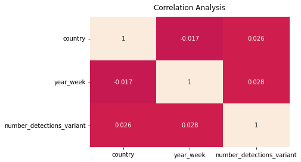

```python
# EU beta variant OLS Regression Result and correlation analysis
ols_location_time(eu_data_beta)
```

```
                                OLS Regression Results
=====================================================================================
Dep. Variable:     number_detections_variant   R-squared:                       0.268
Model:                                   OLS   Adj. R-squared:                  0.258
Method:                        Least Squares   F-statistic:                     25.52
Date:                       Sat, 04 Dec 2021   Prob (F-statistic):          6.00e-119
Time:                               10:01:38   Log-Likelihood:                -9805.2
No. Observations:                       2117   AIC:                         1.967e+04
Df Residuals:                           2086   BIC:                         1.985e+04
Df Model:                                 30
Covariance Type:                   nonrobust
============================================================================================
                               coef    std err          t      P>|t|      [0.025      0.975]
--------------------------------------------------------------------------------------------
Intercept                   -3.4378      3.082     -1.115      0.265      -9.483       2.607
country[T.Belgium]          38.3156      4.195      9.134      0.000      30.089      46.542
country[T.Bulgaria]         -1.9204      4.196     -0.458      0.647     -10.149       6.308
country[T.Croatia]          -1.8458      4.409     -0.419      0.676     -10.492       6.800
country[T.Cyprus]           -1.9688      4.456     -0.442      0.659     -10.707       6.770
country[T.Czechia]          -1.5352      4.265     -0.360      0.719      -9.900       6.829
country[T.Denmark]          -0.5717      4.061     -0.141      0.888      -8.535       7.392
country[T.Estonia]          -1.9614      4.117     -0.476      0.634     -10.036       6.113
country[T.Finland]          -1.6791      4.323     -0.388      0.698     -10.157       6.799
country[T.France]           31.6979      4.075      7.779      0.000      23.707      39.689
country[T.Germany]          12.4593      3.997      3.117      0.002       4.620      20.299
country[T.Greece]           -1.9651      4.323     -0.455      0.649     -10.443       6.513
country[T.Hungary]          -1.9881      4.432     -0.449      0.654     -10.680       6.703
country[T.Iceland]          -1.5614      4.103     -0.381      0.704      -9.608       6.485
country[T.Ireland]          -1.1144      4.179     -0.267      0.790      -9.310       7.081
country[T.Italy]            51.5877      3.828     13.477      0.000      44.081      59.094
country[T.Latvia]           -1.7915      4.062     -0.441      0.659      -9.758       6.174
country[T.Liechtenstein]    -1.9688      4.456     -0.442      0.659     -10.707       6.770
country[T.Lithuania]        -1.6761      4.036     -0.415      0.678      -9.591       6.239
country[T.Luxembourg]       23.0299      4.088      5.634      0.000      15.013      31.047
country[T.Malta]            -1.0558      4.247     -0.249      0.804      -9.384       7.273
country[T.Netherlands]       9.1583      3.974      2.305      0.021       1.365      16.952
country[T.Norway]           -1.7223      4.229     -0.407      0.684     -10.017       6.572
country[T.Poland]           -1.5890      4.212     -0.377      0.706      -9.848       6.670
country[T.Portugal]          2.4501      3.974      0.617      0.538      -5.343      10.244
country[T.Romania]          -1.3864      3.999     -0.347      0.729      -9.228       6.456
country[T.Slovakia]         -1.9688      4.456     -0.442      0.659     -10.707       6.770
country[T.Slovenia]         -1.8146      4.284     -0.424      0.672     -10.216       6.587
country[T.Spain]            24.2247      3.930      6.164      0.000      16.517      31.932
country[T.Sweden]            2.2931      3.910      0.586      0.558      -5.376       9.962
year_week                    0.1966      0.037      5.249      0.000       0.123       0.270
==============================================================================
Omnibus:                     2126.401   Durbin-Watson:                   1.336
Prob(Omnibus):                  0.000   Jarque-Bera (JB):           150550.130
Skew:                           4.757   Prob(JB):                         0.00
Kurtosis:                      43.203   Cond. No.                         941.
==============================================================================

Notes:
[1] Standard Errors assume that the covariance matrix of the errors is correctly specified.
```

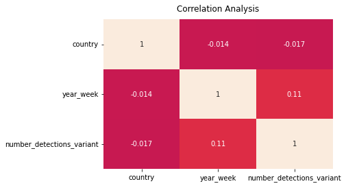

```python
# EU gamma variant OLS Regression Result and correlation analysis
ols_location_time(eu_data_gamma)
```

```
                                OLS Regression Results
=====================================================================================
Dep. Variable:     number_detections_variant   R-squared:                       0.260
Model:                                   OLS   Adj. R-squared:                  0.251
Method:                        Least Squares   F-statistic:                     26.98
Date:                       Sat, 04 Dec 2021   Prob (F-statistic):          1.65e-127
Time:                               10:01:38   Log-Likelihood:                -19393.
No. Observations:                       2330   AIC:                         3.885e+04
Df Residuals:                           2299   BIC:                         3.903e+04
Df Model:                                 30
Covariance Type:                   nonrobust
============================================================================================
                               coef    std err          t      P>|t|      [0.025      0.975]
--------------------------------------------------------------------------------------------
Intercept                  151.4709    119.703      1.265      0.206     -83.266     386.208
country[T.Belgium]        -368.4354    160.790     -2.291      0.022    -683.744     -53.127
country[T.Bulgaria]       -825.3810    164.380     -5.021      0.000   -1147.730    -503.032
country[T.Croatia]        -808.0261    166.410     -4.856      0.000   -1134.355    -481.697
country[T.Cyprus]         -884.0282    160.793     -5.498      0.000   -1199.342    -568.714
country[T.Czechia]        -815.6049    159.182     -5.124      0.000   -1127.760    -503.450
country[T.Denmark]         538.5993    159.702      3.373      0.001     225.424     851.774
country[T.Estonia]        -839.9028    160.240     -5.242      0.000   -1154.132    -525.673
country[T.Finland]        -701.7670    154.528     -4.541      0.000   -1004.796    -398.738
country[T.France]         1063.4172    160.790      6.614      0.000     748.109    1378.726
country[T.Germany]         450.3686    157.187      2.865      0.004     142.125     758.612
country[T.Greece]         -755.5828    158.159     -4.777      0.000   -1065.733    -445.433
country[T.Hungary]        -867.3643    164.380     -5.277      0.000   -1189.713    -545.015
country[T.Iceland]        -776.3718    162.521     -4.777      0.000   -1095.076    -457.668
country[T.Ireland]        -518.7727    158.160     -3.280      0.001    -828.923    -208.622
country[T.Italy]          -360.9582    147.893     -2.441      0.015    -650.975     -70.941
country[T.Latvia]         -861.0269    161.353     -5.336      0.000   -1177.440    -544.614
country[T.Liechtenstein]  -803.1150    176.384     -4.553      0.000   -1149.002    -457.228
country[T.Lithuania]      -719.2070    162.521     -4.425      0.000   -1037.910    -400.503
country[T.Luxembourg]     -861.3739    158.159     -5.446      0.000   -1171.524    -551.224
country[T.Malta]          -891.4611    161.355     -5.525      0.000   -1207.877    -575.045
country[T.Netherlands]    -372.4901    159.178     -2.340      0.019    -684.637     -60.343
country[T.Norway]         -461.3414    158.159     -2.917      0.004    -771.491    -151.191
country[T.Poland]         -795.4288    157.667     -5.045      0.000   -1104.614    -486.243
country[T.Portugal]       -685.2777    157.668     -4.346      0.000    -994.464    -376.091
country[T.Romania]        -848.9557    161.353     -5.261      0.000   -1165.368    -532.543
country[T.Slovakia]       -809.3234    161.929     -4.998      0.000   -1126.867    -491.780
country[T.Slovenia]       -683.7064    160.240     -4.267      0.000    -997.936    -369.476
country[T.Spain]          -366.0944    149.763     -2.444      0.015    -659.780     -72.409
country[T.Sweden]         -251.8533    157.186     -1.602      0.109    -560.095      56.388
year_week                   23.7116      1.362     17.404      0.000      21.040      26.383
==============================================================================
Omnibus:                     2621.367   Durbin-Watson:                   1.291
Prob(Omnibus):                  0.000   Jarque-Bera (JB):           324545.415
Skew:                           5.578   Prob(JB):                         0.00
Kurtosis:                      59.732   Cond. No.                     1.04e+03
==============================================================================

Notes:
[1] Standard Errors assume that the covariance matrix of the errors is correctly specified.
[2] The condition number is large, 1.04e+03. This might indicate that there are
strong multicollinearity or other numerical problems.
```

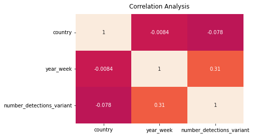

```python
# EU delta variant OLS Regression Result and correlation analysis
ols_location_time(eu_data_delta)
```

#### Overal Analysis For the Whole EU data

**OLS Regression**

With most p<0.05 and p=0 in most cases, it has shown strong evidence that the location(country) and time(year_week) affect the spread of a certain variant and overall(all variant data combined). Some tests that result p>0.05 and have tvalue that close to 0, indicating there might be a lack of sample to have a similar result like the other.

**Correlation Analysis**

Based on this analysis it is further strengthen the fact that the time frame matter and shown on the eu_data_delta and eu_data heatmap. Therefore, we need to make further correlation analysis and separate the data based on a certain time frame.

```python
def corr_eu(data):
    eu_data_var = data.copy()

    for i in range(len(week)):
        eu_data_var.replace(to_replace = week['year_week'][i], value = (i + 1), inplace= True)

    for i in range(len(country_eu['country'])):
        eu_data_var.replace(to_replace = country_eu['country'][i], value = (i + 1), inplace= True)

    fig, axs = plt.subplots(nrows = 1, ncols = 3, figsize = (25,6))
    sns.heatmap(eu_data_var.loc[(eu_data_var['year_week'] >= 1) & (eu_data_var['year_week'] <= 18)].corr(), vmin=-1, vmax=1, annot=True, ax = axs[0], cbar=False).set_title("Week 1 to 18", fontdict={'fontsize':20}, pad=12);
    sns.heatmap(eu_data_var.loc[(eu_data_var['year_week'] >= 19) & (eu_data_var['year_week'] <= 36)].corr(), vmin=-1, vmax=1, annot=True, ax = axs[1], cbar=False).set_title("Week 19 to 36", fontdict={'fontsize':20}, pad=12);
    sns.heatmap(eu_data_var.loc[(eu_data_var['year_week'] >= 37) & (eu_data_var['year_week'] <= 54)].corr(), vmin=-1, vmax=1, annot=True, ax = axs[2], cbar=False).set_title("Week 37 to 54", fontdict={'fontsize':20}, pad=12);
```

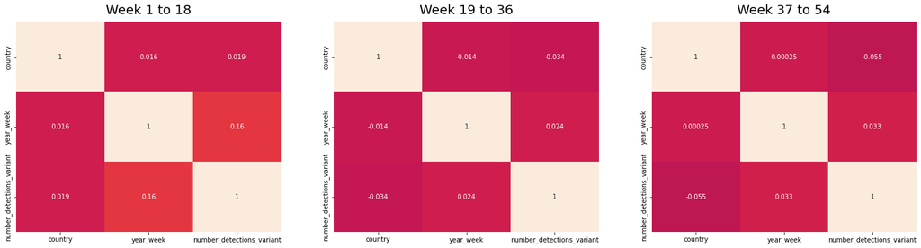

```python
# EU correlation analysis during different time frame
corr_eu(eu_data)
```

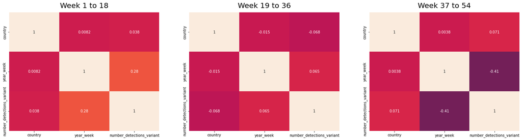

```python
# EU ALPHA VARIANT correlation analysis during different time frame
corr_eu(eu_data_alpha)
```

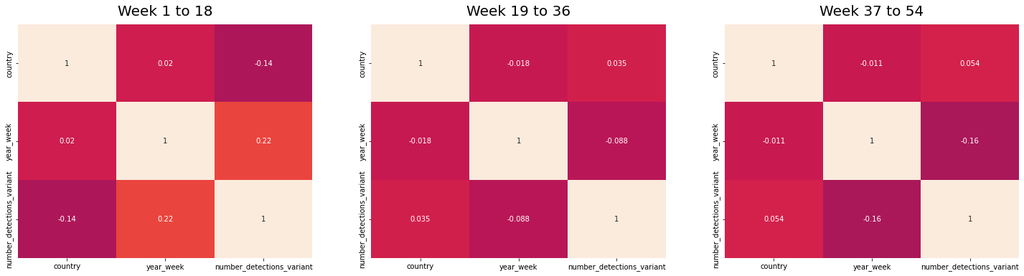

```python
# EU BETA VARIANT correlation analysis during different time frame
corr_eu(eu_data_beta)
```

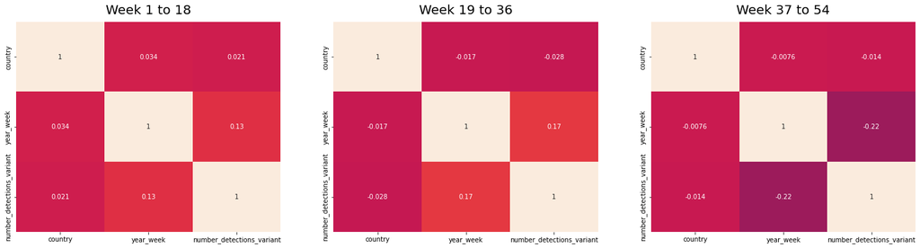

```python
# EU GAMMA VARIANT correlation analysis during different time frame
corr_eu(eu_data_gamma)
```

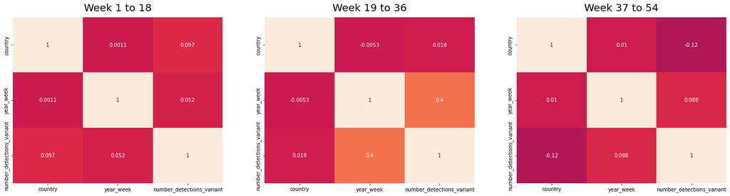

```python
# EU DELTA VARIANT correlation analysis during different time frame
corr_eu(eu_data_delta)
```

#### Overal Analysis For EU data Heatmap

After observing the heatmap, noticed that there is a pattern that applies to all COVID-19 variants of concern.

Further strengthening the fact that **the outbreak of each variant mostly happened at different locations during the same period of time with the same pattern of spreading.**

## World Data

### World Data Graph

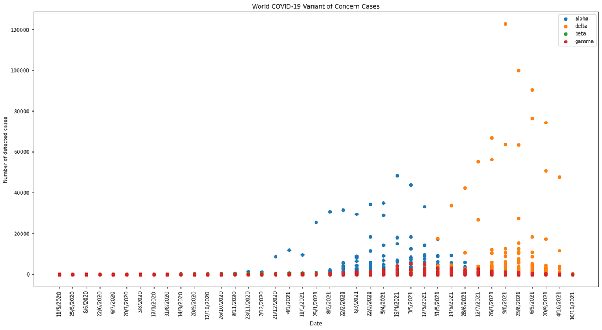

```python
# Overal world data variant of concern cases
plt.figure(figsize=(20, 10))
plt.xticks(rotation=90)
plt.xlabel("Date")
plt.ylabel("Number of detected cases")
plt.title("World COVID-19 Variant of Concern Cases")
plt.scatter(world_data_alpha.date, world_data_alpha.num_sequences, label="alpha")
plt.scatter(world_data_delta.date, world_data_delta.num_sequences, label="delta")
plt.scatter(world_data_beta.date, world_data_beta.num_sequences, label="beta")
plt.scatter(world_data_gamma.date, world_data_gamma.num_sequences, label="gamma")
plt.legend()
```

By observing the graph, **it is also similar to the Europe data that each COVID-19 mutation spread across different locations in the same time frame.**

### World Data Regression and Correlation

```python
# drop duplicate data
week = world_data.copy()
week = week.drop(columns=['variant', 'num_sequences', 'location'])
week = week.drop_duplicates(subset = ['date'])
week.reset_index(drop=True, inplace=True)
```

```python
# get list of countries
location_world = world_data.copy()
location_world = location_world.drop(columns=['variant', 'num_sequences', 'date'])
location_world = location_world.drop_duplicates(subset = ['location'])
location_world.reset_index(drop=True, inplace=True)
```

```python
def ols_world(data):
    world_data_var = data.copy()

    for i in range(len(week)):
        world_data_var.replace(to_replace = week['date'][i], value = (i + 1), inplace= True)

    result = sm.ols(formula="num_sequences ~ location + date", data=world_data_var).fit()
    print(result.summary())

    for i in range(len(location_world['location'])):
        world_data_var.replace(to_replace = location_world['location'][i], value = (i + 1), inplace= True)
    sns.heatmap(world_data_var.corr(), vmin=-1, vmax=1, annot=True, cmap="Blues_r", cbar=False).set_title("Correlation Analysis", fontdict={'fontsize':12}, pad=12);
```

```
                            OLS Regression Results
==============================================================================
Dep. Variable:          num_sequences   R-squared:                       0.096
Model:                            OLS   Adj. R-squared:                  0.082
Method:                 Least Squares   F-statistic:                     6.958
Date:                Sat, 04 Dec 2021   Prob (F-statistic):           2.02e-89
Time:                        10:01:40   Log-Likelihood:                -67610.
No. Observations:                7072   AIC:                         1.354e+05
Df Residuals:                    6965   BIC:                         1.362e+05
Df Model:                         106
Covariance Type:            nonrobust
=========================================================================================================
                                            coef    std err          t      P>|t|      [0.025      0.975]
---------------------------------------------------------------------------------------------------------
Intercept                             -1145.6544    532.162     -2.153      0.031   -2188.854    -102.455
location[T.Argentina]                   303.3776    600.658      0.505      0.614    -874.096    1480.851
location[T.Aruba]                      -197.5602    677.798     -0.291      0.771   -1526.250    1131.129
location[T.Australia]                   323.9588    592.623      0.547      0.585    -837.763    1485.681
location[T.Austria]                     179.6344    607.190      0.296      0.767   -1010.643    1369.912
location[T.Bahrain]                    -155.0606    755.938     -0.205      0.837   -1636.929    1326.808
location[T.Bangladesh]                  160.9247    618.910      0.260      0.795   -1052.328    1374.177
location[T.Belgium]                     480.1467    594.351      0.808      0.419    -684.961    1645.255
location[T.Botswana]                   -256.4711    933.347     -0.275      0.783   -2086.115    1573.173
location[T.Brazil]                      459.4719    592.623      0.775      0.438    -702.250    1621.194
location[T.Bulgaria]                    -29.5421    686.716     -0.043      0.966   -1375.715    1316.631
location[T.Cambodia]                   -348.8488    761.579     -0.458      0.647   -1841.776    1144.079
location[T.Canada]                      750.0253    594.497      1.262      0.207    -415.370    1915.421
location[T.Chile]                       227.6443    607.330      0.375      0.708    -962.907    1418.196
location[T.China]                      -365.4514   1807.010     -0.202      0.840   -3907.741    3176.838
location[T.Colombia]                    -69.5047    694.288     -0.100      0.920   -1430.522    1291.512
location[T.Costa Rica]                 -211.1041    686.916     -0.307      0.759   -1557.668    1135.460
location[T.Croatia]                     -67.1006    677.651     -0.099      0.921   -1395.504    1261.303
location[T.Curacao]                    -240.6870    777.802     -0.309      0.757   -1765.416    1284.042
location[T.Czechia]                     -29.1960    634.188     -0.046      0.963   -1272.397    1214.005
location[T.Denmark]                     984.9127    592.623      1.662      0.097    -176.809    2146.635
location[T.Djibouti]                     24.0751   1329.700      0.018      0.986   -2582.543    2630.693
location[T.Dominican Republic]          -51.9877   1126.686     -0.046      0.963   -2260.635    2156.659
location[T.Ecuador]                    -281.8261    819.561     -0.344      0.731   -1888.416    1324.764
location[T.Estonia]                      -5.3728    686.688     -0.008      0.994   -1351.491    1340.746
location[T.Eswatini]                   -341.9514   2501.490     -0.137      0.891   -5245.635    4561.732
```

[output cut: 77 more lines]

```
location[T.Vietnam]                    -412.1391   1330.259     -0.310      0.757   -3019.851    2195.573
location[T.Zambia]                      150.4248    796.802      0.189      0.850   -1411.550    1712.400
location[T.Zimbabwe]                    296.9198   1010.314      0.294      0.769   -1683.603    2277.442
date                                     47.5502      4.340     10.956      0.000      39.042      56.058
==============================================================================
Omnibus:                    14782.209   Durbin-Watson:                   2.167
Prob(Omnibus):                  0.000   Jarque-Bera (JB):         56834848.904
Skew:                          17.933   Prob(JB):                         0.00
Kurtosis:                     440.712   Cond. No.                     3.21e+03
==============================================================================

Notes:
[1] Standard Errors assume that the covariance matrix of the errors is correctly specified.
[2] The condition number is large, 3.21e+03. This might indicate that there are
strong multicollinearity or other numerical problems.
```

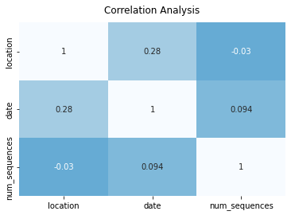

```python
# world variant of concern cases OLS Regression Result and correlation analysis
ols_world(world_data)
```

```
                            OLS Regression Results
==============================================================================
Dep. Variable:          num_sequences   R-squared:                       0.217
Model:                            OLS   Adj. R-squared:                  0.173
Method:                 Least Squares   F-statistic:                     4.899
Date:                Sat, 04 Dec 2021   Prob (F-statistic):           1.06e-45
Time:                        10:01:40   Log-Likelihood:                -17642.
No. Observations:                1902   AIC:                         3.549e+04
Df Residuals:                    1799   BIC:                         3.606e+04
Df Model:                         102
Covariance Type:            nonrobust
=========================================================================================================
                                            coef    std err          t      P>|t|      [0.025      0.975]
---------------------------------------------------------------------------------------------------------
Intercept                              -860.7992    815.953     -1.055      0.292   -2461.114     739.516
location[T.Argentina]                   225.0906    921.854      0.244      0.807   -1582.927    2033.108
location[T.Aruba]                      -139.3192   1040.278     -0.134      0.893   -2179.598    1900.960
location[T.Australia]                   176.6227    909.543      0.194      0.846   -1607.249    1960.494
location[T.Austria]                     201.1064    931.920      0.216      0.829   -1626.654    2028.866
location[T.Bahrain]                    -127.1180   1160.221     -0.110      0.913   -2402.640    2148.403
location[T.Bangladesh]                  111.6879    949.904      0.118      0.906   -1751.344    1974.720
location[T.Belgium]                     716.1980    912.199      0.785      0.432   -1072.883    2505.279
location[T.Brazil]                      179.9648    909.543      0.198      0.843   -1603.907    1963.836
location[T.Bulgaria]                     65.0161    996.697      0.065      0.948   -1889.789    2019.822
location[T.Cambodia]                   -230.1368   1088.778     -0.211      0.833   -2365.540    1905.266
location[T.Canada]                      950.8386    912.413      1.042      0.297    -838.661    2740.338
location[T.Chile]                       142.9007    932.124      0.153      0.878   -1685.259    1971.061
location[T.China]                      -285.4445   2773.417     -0.103      0.918   -5724.902    5154.013
location[T.Colombia]                    -59.9112   1005.913     -0.060      0.953   -2032.791    1912.969
location[T.Costa Rica]                 -158.9655   1054.274     -0.151      0.880   -2226.696    1908.765
location[T.Croatia]                     138.1210   1040.065      0.133      0.894   -1901.741    2177.983
location[T.Curacao]                    -172.8109   1108.728     -0.156      0.876   -2347.340    2001.719
location[T.Czechia]                     106.9100    973.361      0.110      0.913   -1802.127    2015.947
location[T.Denmark]                    1819.7017    909.543      2.001      0.046      35.830    3603.573
location[T.Djibouti]                     17.1164   1550.142      0.011      0.991   -3023.151    3057.384
location[T.Dominican Republic]          -41.4087   1550.151     -0.027      0.979   -3081.694    2998.876
location[T.Ecuador]                    -208.4144   1160.702     -0.180      0.858   -2484.880    2068.051
location[T.Estonia]                      92.0672    996.654      0.092      0.926   -1862.653    2046.788
location[T.Ethiopia]                   -374.9948   2041.914     -0.184      0.854   -4379.767    3629.777
location[T.Fiji]                       -249.6244   1729.790     -0.144      0.885   -3642.232    3142.984
```

[output cut: 73 more lines]

```
location[T.United States]              6267.8069    909.543      6.891      0.000    4483.936    8051.678
location[T.Vietnam]                    -329.7197   1551.212     -0.213      0.832   -3372.087    2712.647
location[T.Zambia]                      102.3367   1132.250      0.090      0.928   -2118.327    2323.001
date                                     35.8201      6.489      5.520      0.000      23.093      48.548
==============================================================================
Omnibus:                     2621.302   Durbin-Watson:                   1.594
Prob(Omnibus):                  0.000   Jarque-Bera (JB):           760003.346
Skew:                           7.707   Prob(JB):                         0.00
Kurtosis:                      99.708   Cond. No.                     3.26e+03
==============================================================================

Notes:
[1] Standard Errors assume that the covariance matrix of the errors is correctly specified.
[2] The condition number is large, 3.26e+03. This might indicate that there are
strong multicollinearity or other numerical problems.
```

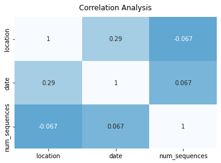

```python
# World ALPHA variant OLS Regression Result and correlation analysis
ols_world(world_data_alpha)
```

```
                            OLS Regression Results
==============================================================================
Dep. Variable:          num_sequences   R-squared:                       0.287
Model:                            OLS   Adj. R-squared:                  0.252
Method:                 Least Squares   F-statistic:                     8.129
Date:                Sat, 04 Dec 2021   Prob (F-statistic):           1.52e-76
Time:                        10:01:40   Log-Likelihood:                -9896.7
No. Observations:                1783   AIC:                         1.996e+04
Df Residuals:                    1698   BIC:                         2.043e+04
Df Model:                          84
Covariance Type:            nonrobust
=========================================================================================================
                                            coef    std err          t      P>|t|      [0.025      0.975]
---------------------------------------------------------------------------------------------------------
Intercept                                11.1054     19.626      0.566      0.572     -27.388      49.599
location[T.Argentina]                   -29.5053     22.161     -1.331      0.183     -72.970      13.960
location[T.Aruba]                       -40.4674     25.007     -1.618      0.106     -89.515       8.580
location[T.Australia]                   -28.6294     21.864     -1.309      0.191     -71.513      14.255
location[T.Austria]                     -24.5925     22.402     -1.098      0.272     -68.531      19.346
location[T.Bahrain]                     -38.8124     27.890     -1.392      0.164     -93.515      15.890
location[T.Bangladesh]                  -17.4192     22.834     -0.763      0.446     -62.206      27.367
location[T.Belgium]                      -1.3442     21.928     -0.061      0.951     -44.353      41.665
location[T.Botswana]                    -12.7814     27.901     -0.458      0.647     -67.506      41.943
location[T.Brazil]                      -30.9452     21.864     -1.415      0.157     -73.829      11.939
location[T.Bulgaria]                    -38.1318     23.959     -1.592      0.112     -85.124       8.861
location[T.Cambodia]                    -43.8453     26.173     -1.675      0.094     -95.181       7.490
location[T.Canada]                      -14.3201     21.933     -0.653      0.514     -57.340      28.699
location[T.Chile]                       -31.7846     22.407     -1.419      0.156     -75.733      12.164
location[T.China]                       -43.9222     66.669     -0.659      0.510    -174.684      86.840
location[T.Costa Rica]                  -39.8388     25.343     -1.572      0.116     -89.546       9.869
location[T.Croatia]                     -36.7448     25.002     -1.470      0.142     -85.782      12.292
location[T.Czechia]                     -34.9117     23.398     -1.492      0.136     -80.804      10.981
location[T.Denmark]                     -27.6821     21.864     -1.266      0.206     -70.566      15.202
location[T.Djibouti]                    -12.4680     37.263     -0.335      0.738     -85.554      60.618
location[T.Estonia]                     -35.8678     23.958     -1.497      0.135     -82.858      11.123
location[T.Eswatini]                    -41.9222     66.669     -0.629      0.530    -172.684      88.840
location[T.Ethiopia]                    -46.4860     49.085     -0.947      0.344    -142.760      49.788
location[T.Finland]                       8.7653     22.604      0.388      0.698     -35.570      53.101
location[T.France]                      122.8193     21.928      5.601      0.000      79.810     165.829
location[T.Germany]                      28.8179     21.864      1.318      0.188     -14.066      71.702
```

[output cut: 55 more lines]

```
location[T.United States]                46.8706     21.864      2.144      0.032       3.987      89.755
location[T.Zambia]                      -24.8279     27.218     -0.912      0.362     -78.212      28.556
location[T.Zimbabwe]                     10.4256     29.670      0.351      0.725     -47.768      68.619
date                                      1.0255      0.158      6.472      0.000       0.715       1.336
==============================================================================
Omnibus:                     1534.684   Durbin-Watson:                   1.612
Prob(Omnibus):                  0.000   Jarque-Bera (JB):            65138.991
Skew:                           3.829   Prob(JB):                         0.00
Kurtosis:                      31.603   Cond. No.                     2.85e+03
==============================================================================

Notes:
[1] Standard Errors assume that the covariance matrix of the errors is correctly specified.
[2] The condition number is large, 2.85e+03. This might indicate that there are
strong multicollinearity or other numerical problems.
```

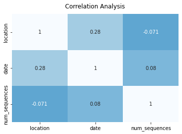

```python
# World BETA variant OLS Regression Result and correlation analysis
ols_world(world_data_beta)
```

```
                            OLS Regression Results
==============================================================================
Dep. Variable:          num_sequences   R-squared:                       0.259
Model:                            OLS   Adj. R-squared:                  0.226
Method:                 Least Squares   F-statistic:                     7.860
Date:                Sat, 04 Dec 2021   Prob (F-statistic):           9.93e-57
Time:                        10:01:41   Log-Likelihood:                -10509.
No. Observations:                1481   AIC:                         2.115e+04
Df Residuals:                    1417   BIC:                         2.149e+04
Df Model:                          63
Covariance Type:            nonrobust
=========================================================================================================
                                            coef    std err          t      P>|t|      [0.025      0.975]
---------------------------------------------------------------------------------------------------------
Intercept                              -138.3798     92.129     -1.502      0.133    -319.104      42.344
location[T.Argentina]                    74.5087    103.695      0.719      0.473    -128.903     277.921
location[T.Aruba]                       -19.2312    117.000     -0.164      0.869    -248.744     210.281
location[T.Australia]                    27.7621    102.301      0.271      0.786    -172.916     228.440
location[T.Austria]                      16.5751    104.809      0.158      0.874    -189.021     222.172
location[T.Bahrain]                     -18.9531    130.484     -0.145      0.885    -274.916     237.010
location[T.Bangladesh]                   19.0634    106.833      0.178      0.858    -190.504     228.631
location[T.Belgium]                      79.2062    102.597      0.772      0.440    -122.053     280.465
location[T.Brazil]                      756.2095    102.301      7.392      0.000     555.532     956.887
location[T.Canada]                      358.3122    102.627      3.491      0.000     156.996     559.628
location[T.Chile]                       156.9630    104.836      1.497      0.135     -48.688     362.614
location[T.China]                       -43.4922    311.911     -0.139      0.889    -655.349     568.365
location[T.Colombia]                     25.0492    113.127      0.221      0.825    -196.865     246.963
location[T.Costa Rica]                  -15.2594    118.574     -0.129      0.898    -247.858     217.339
location[T.Croatia]                     -17.5414    116.971     -0.150      0.881    -246.997     211.914
location[T.Curacao]                     -28.9501    124.700     -0.232      0.816    -273.567     215.667
location[T.Czechia]                     -11.2398    109.467     -0.103      0.918    -225.975     203.495
location[T.Denmark]                      29.2884    102.301      0.286      0.775    -171.389     229.966
location[T.Dominican Republic]            1.6214    174.331      0.009      0.993    -340.354     343.597
location[T.Ecuador]                      -9.1669    130.550     -0.070      0.944    -265.258     246.925
location[T.Finland]                      18.1136    105.756      0.171      0.864    -189.342     225.570
location[T.France]                       54.2161    102.599      0.528      0.597    -147.046     255.478
location[T.Germany]                      49.6568    102.301      0.485      0.627    -151.021     250.334
location[T.Ghana]                        -2.3116    115.535     -0.020      0.984    -228.949     224.326
location[T.Greece]                        5.3329    108.716      0.049      0.961    -207.930     218.595
location[T.Guatemala]                     2.8049    138.736      0.020      0.984    -269.344     274.954
```

[output cut: 34 more lines]

```
location[T.United Kingdom]               33.3147    102.301      0.326      0.745    -167.363     233.992
location[T.United States]               745.1042    102.301      7.283      0.000     544.427     945.782
location[T.Uruguay]                      32.5165    144.363      0.225      0.822    -250.672     315.705
date                                      5.6835      0.804      7.071      0.000       4.107       7.260
==============================================================================
Omnibus:                     1948.336   Durbin-Watson:                   1.660
Prob(Omnibus):                  0.000   Jarque-Bera (JB):           451016.917
Skew:                           7.034   Prob(JB):                         0.00
Kurtosis:                      87.326   Cond. No.                     2.24e+03
==============================================================================

Notes:
[1] Standard Errors assume that the covariance matrix of the errors is correctly specified.
[2] The condition number is large, 2.24e+03. This might indicate that there are
strong multicollinearity or other numerical problems.
```

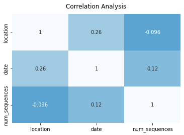

```python
# World GAMMA variant OLS Regression Result and correlation analysis
ols_world(world_data_gamma)
```

```
                            OLS Regression Results
==============================================================================
Dep. Variable:          num_sequences   R-squared:                       0.217
Model:                            OLS   Adj. R-squared:                  0.172
Method:                 Least Squares   F-statistic:                     4.890
Date:                Sat, 04 Dec 2021   Prob (F-statistic):           1.37e-45
Time:                        10:01:41   Log-Likelihood:                -19137.
No. Observations:                1906   AIC:                         3.848e+04
Df Residuals:                    1803   BIC:                         3.905e+04
Df Model:                         102
Covariance Type:            nonrobust
=========================================================================================================
                                            coef    std err          t      P>|t|      [0.025      0.975]
---------------------------------------------------------------------------------------------------------
Intercept                             -3373.9120   1753.470     -1.924      0.054   -6812.958      65.134
location[T.Argentina]                   885.5223   1981.151      0.447      0.655   -3000.071    4771.115
location[T.Aruba]                      -550.3690   2235.657     -0.246      0.806   -4935.120    3834.382
location[T.Australia]                  1076.0357   1954.695      0.550      0.582   -2757.669    4909.740
location[T.Austria]                     500.5385   2002.788      0.250      0.803   -3427.491    4428.568
location[T.Bahrain]                    -405.1454   2493.428     -0.162      0.871   -5295.458    4485.167
location[T.Bangladesh]                  499.9063   2041.437      0.245      0.807   -3503.925    4503.738
location[T.Belgium]                    1086.5214   1960.404      0.554      0.579   -2758.380    4931.423
location[T.Botswana]                   -782.7081   2494.412     -0.314      0.754   -5674.950    4109.534
location[T.Brazil]                      888.6146   1954.695      0.455      0.649   -2945.090    4722.319
location[T.Bulgaria]                   -198.3565   2142.000     -0.093      0.926   -4399.420    4002.707
location[T.Cambodia]                  -1035.8702   2339.886     -0.443      0.658   -5625.044    3553.303
location[T.Canada]                     1656.6985   1960.861      0.845      0.398   -2189.101    5502.498
location[T.Chile]                       605.6110   2003.225      0.302      0.762   -3323.276    4534.498
location[T.China]                     -1019.7933   5960.347     -0.171      0.864   -1.27e+04    1.07e+04
location[T.Colombia]                   -207.7706   2161.806     -0.096      0.923   -4447.679    4032.138
location[T.Costa Rica]                 -590.7817   2265.737     -0.261      0.794   -5034.528    3852.965
location[T.Croatia]                    -323.8348   2235.201     -0.145      0.885   -4707.691    4060.022
location[T.Curacao]                    -689.5038   2382.763     -0.289      0.772   -5362.771    3983.763
location[T.Czechia]                    -158.3931   2091.849     -0.076      0.940   -4261.096    3944.310
location[T.Denmark]                    2074.2988   1954.695      1.061      0.289   -1759.406    5908.003
location[T.Dominican Republic]         -126.1367   3331.428     -0.038      0.970   -6660.002    6407.728
location[T.Ecuador]                    -834.5696   2494.459     -0.335      0.738   -5726.905    4057.765
location[T.Estonia]                    -137.1178   2141.908     -0.064      0.949   -4338.000    4063.764
location[T.Eswatini]                   -995.7933   5960.347     -0.167      0.867   -1.27e+04    1.07e+04
location[T.Ethiopia]                  -1371.3328   4388.269     -0.312      0.755   -9977.961    7235.295
```

[output cut: 73 more lines]

```
location[T.Vietnam]                   -1189.0631   3333.703     -0.357      0.721   -7727.390    5349.263
location[T.Zambia]                      465.4139   2433.318      0.191      0.848   -4307.005    5237.833
location[T.Zimbabwe]                    836.4718   2652.518      0.315      0.753   -4365.861    6038.804
date                                    138.6158     13.926      9.954      0.000     111.303     165.929
==============================================================================
Omnibus:                     3003.993   Durbin-Watson:                   1.185
Prob(Omnibus):                  0.000   Jarque-Bera (JB):          1744547.366
Skew:                           9.789   Prob(JB):                         0.00
Kurtosis:                     149.914   Cond. No.                     3.27e+03
==============================================================================

Notes:
[1] Standard Errors assume that the covariance matrix of the errors is correctly specified.
[2] The condition number is large, 3.27e+03. This might indicate that there are
strong multicollinearity or other numerical problems.
```

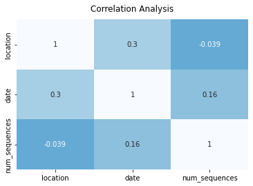

```python
# World DELTA variant OLS Regression Result and correlation analysis
ols_world(world_data_delta)
```

#### OLS Regression Analysis

From this analysis observed that most of the p>0.05 and tvalue close to 0. This might be due to the fact that some country do not have sufficient sample to do the analysis. If we observe each variant regression result, we can be sure that spreading on some location has a similar transmission pattern like the Europe for all COVID-19 Variant of Concern and the date of time also matter since all of them have p < 0.05 and -1 < t or t > 1.

If we observe closer, some countries give more samples on certain variants, thus strengthening the fact that during an outbreak, the location is related to the number of cases.

#### Correlation Analysis

Based on this analysis it is further strengthen the fact that the time frame matter and shown on the world_data_delta, gamma, and world_data heatmap. Therefore, we need to make further correlation analysis and separate the data based on a certain time frame.

```python
def corr_world(data):
    world_data_var = data.copy()

    for i in range(len(week)):
        world_data_var.replace(to_replace = week['date'][i], value = (i + 1), inplace= True)

    for i in range(len(location_world['location'])):
        world_data_var.replace(to_replace = location_world['location'][i], value = (i + 1), inplace= True)

    fig, axs = plt.subplots(nrows = 1, ncols = 3, figsize = (25,6))
    sns.heatmap(world_data_var.loc[(world_data_var['date'] >= 1) & (world_data_var['date'] <= 13)].corr(), vmin=-1, vmax=1, annot=True, ax = axs[0], cmap="Blues_r", cbar=False).set_title("Week 1 to 13", fontdict={'fontsize':20}, pad=12);
    sns.heatmap(world_data_var.loc[(world_data_var['date'] >= 14) & (world_data_var['date'] <= 27)].corr(), vmin=-1, vmax=1, annot=True, ax = axs[1], cmap="Blues_r", cbar=False).set_title("Week 14 to 27", fontdict={'fontsize':20}, pad=12);
    sns.heatmap(world_data_var.loc[(world_data_var['date'] >= 28) & (world_data_var['date'] <= 39)].corr(), vmin=-1, vmax=1, annot=True, ax = axs[2], cmap="Blues_r", cbar=False).set_title("Week 28 to 39", fontdict={'fontsize':20}, pad=12);
```

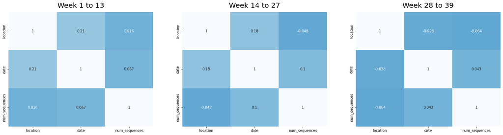

```python
# World variant of concern correlation analysis during different time frame
corr_world(world_data)
```

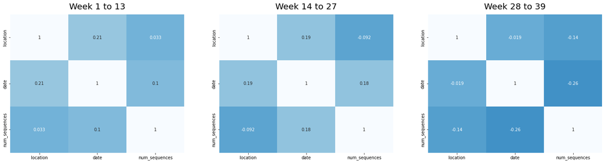

```python
# World ALPHA VARIANT correlation analysis during different time frame
corr_world(world_data_alpha)
```

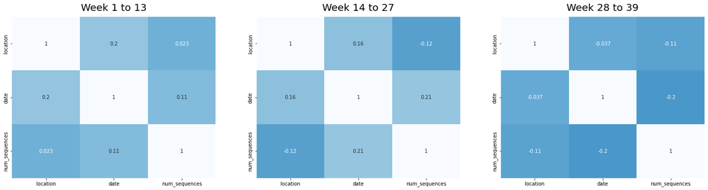

```python
# World BETA VARIANT correlation analysis during different time frame
corr_world(world_data_beta)
```

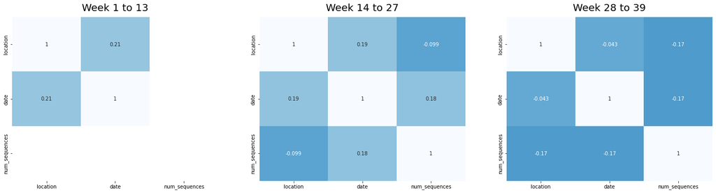

```python
# World GAMMA VARIANT correlation analysis during different time frame
corr_world(world_data_gamma)
```

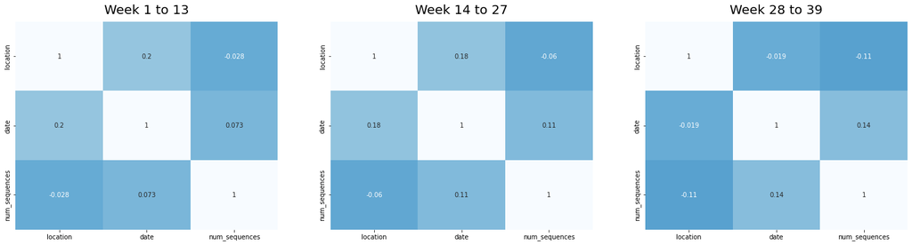

```python
# World DELTA VARIANT correlation analysis during different time frame
corr_world(world_data_delta)
```

#### Heatmap analysis

Further strengthening the fact that **the outbreak of each variant mostly happened at different locations during the same period of time with the same pattern of spreading.**

## Conclusion

From the above analysis, it is shown that all variants have the same pattern. With the observed fact that the outbreak will happen across all locations at the same time frame. Thus it is also shown that **common transition of mutation similar across time and locations.**